# Regressão Linear Múltipla

GUILHERME OLIVEIRA CASAGRANDE

2023-11-14

## Exemplo 1 - volume de negociações no mercado à vista na B3

Neste exemplo, vamos entender quais são os fatores que afetam o volume de transações no mercado à vista na B3 por pessoas físicas, tendo como variáveis regressoras: IPCA, TAXA DE JUROS, PIB, POUPANÇA e EMBI+.

O EMBI+ é a sigla para o chamado *Emerging Markets Bond Index Plus*, ou seja, o Índice de Títulos da Dívida de Mercados Emergentes, criado pelo Banco estadunidense JP Morgan ainda na década de 1990. O objetivo principal do EMBI+ é medir o desempenho dos títulos públicos emitidos em 19 países considerados emergentes ou em desenvolvimento.

Todas as variáveis estão apresentadas em variação percentual.

Objetivo: identificar quais variáveis são as que mais afetam o volume de transações e de forma ocorre o efeito (análise dos coeficientes angulares das variáveis que permanecerem no modelo). **Use alfa = 10%**.

### Etapa descritiva

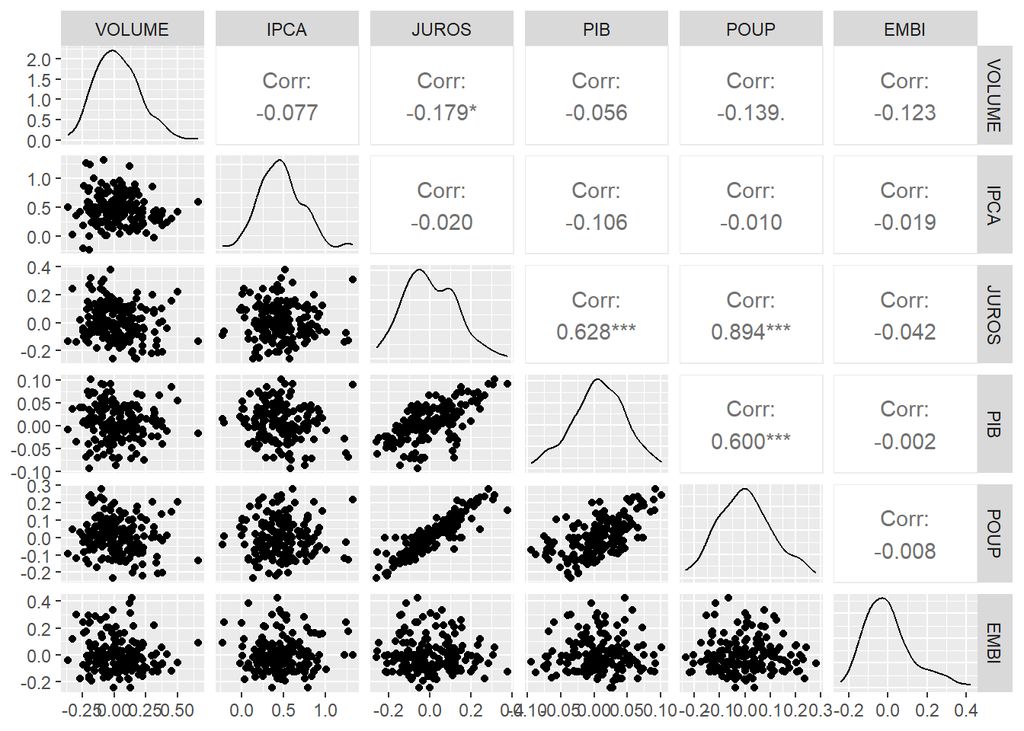

O gráfico acima apresenta na matriz triângulo superior as correlações entre as variáveis. Na matriz triângulo inferior aparecem os diagramas de dispersão 2 a 2. Na diagonal principal aparecem esboços das distribuições de probabilidade de cada uma das variáveis.

Um primeiro problema que o gráfico nos revela é a correlação alta entre as variáveis supostamente independentes: POUP e JUROS (=0.894). Num modelo de regressão múltipla, as variáveis independentes precisam ser de fato independentes.

Quando as variáveis independentes apresentam relação entre si, esse problema é chamado do MULTICOLINEARIDADE. Para detectar se de fato ele ocorre, utilizamos uma medida chamada VIF (Variance Inflation Factor). Se o VIF for maior do que 5, precisamos eliminar a variável independente do modelo.

VIF com todas as variáveis

|  | x |
| --- | --- |
| IPCA | 1.02 |
| JUROS | 5.36 |
| PIB | 1.70 |
| POUP | 5.06 |
| EMBI | 1.01 |

O vif = 1/(1 - R²). O R² foi obtido supondo que a variável que aparece associada ao VIF é o y.

R² = mostra a % de explicação de uma regressão. Quanto mais próximo de 1, maior a explicação.

IPCA = JUROS + PIB + POUP + EMBI ( 1.016454 )

(…)

JUROS = IPCA + PIB + POUP + EMBI (5.357400)

POUP = JUROS + IPCA + PIB + EMBI (5.059556)

Dois VIFs foram detectados como maiores do que 5. Então a dica é eliminar a variável x que possui a menor correlação, em módulo, com a variável y original (VOLUME).

A análise das correlações indica que a variável POUP é a que possui a menor correlação, em módulo, com o VOLUME (=-0.139).

VIF sem a variável POUP

|  | x |
| --- | --- |
| IPCA | 1.02 |
| JUROS | 1.66 |
| PIB | 1.68 |
| EMBI | 1.00 |

Eliminar uma variável x muito correlacionada com outra não é problema algum. A variável que permanece no modelo “responde pelas duas”.

### Etapa inferencial

Resultados preliminares

|  | Estimate | Std. Error | t value | Pr(>\|t\|) |
| --- | --- | --- | --- | --- |
| (Intercept) | 0.05 | 0.03 | 1.83 | 0.07 |
| IPCA | -0.05 | 0.05 | -0.99 | 0.33 |
| JUROS | -0.33 | 0.13 | -2.48 | 0.01 |
| PIB | 0.39 | 0.44 | 0.90 | 0.37 |
| EMBI | -0.19 | 0.10 | -1.78 | 0.08 |

Marginalmente, as variáveis IPCA e PIB são irrelevantes para a predição do volume de negociações no mercado à vista (valores-p na coluna Pr marginais são maiores do que 10%). Já as variáveis JUROS e EMBI são significativas marginalmente (valores-p menores do que 10%).

Para saber quais variáveis ficam e quais variáveis saem do modelo, utilizaremos um processo de seleção automático chamado *backward stepwise*. O critério utilizado é chamado de critério de informação de Akaike (AIC). Quanto menor o AIC, melhor o ajuste.

O valor-p global só aparece se visualizarmos o conteúdo do objeto resultado3. As hipóteses são:

- Ho: o modelo não é útil
- Ha: o modelo é útil

Resultados finais

|  | Estimate | Std. Error | t value | Pr(>\|t\|) |
| --- | --- | --- | --- | --- |
| (Intercept) | 0.03 | 0.01 | 2.27 | 0.02 |
| JUROS | -0.25 | 0.10 | -2.45 | 0.02 |
| EMBI | -0.18 | 0.10 | -1.73 | 0.08 |

A equação de regressão final fica:

$$Volume = 0.03 -0.25*Juros -0.18*EMBI$$

O coeficiente linear igual a $0.03$ indica que quando as duas outras variáveis forem iguais a zero, espera-se um volume de transações no mercado à vista de 3% (0.03 = 3%). As variações percentuais iguais a zero indicam um momento de estabilidade da taxa de juros e do EMBI+.

Já o coeficiente angular $|-0,25|$ indica o decréscimo médio na variação do volume de negociações no mercado à vista, quando a variação da taxa de juros aumenta em uma unidade, supondo que EMBI seja constante (ceteris paribus).

O outro coeficiente angular $|-0,18|$ é o decréscimo médio dado à variação do volume de negociações no mercado à vista, quando a variação do EMBI+ aumenta em uma unidade, ceteris paribus.

As variações dos coeficientes aparecem na próxima tabela:

Intervalos de variação dos coeficientes com 90% de confiança

|  | 5 % | 95 % |
| --- | --- | --- |
| (Intercept) | 0.01 | 0.05 |
| JUROS | -0.43 | -0.08 |
| EMBI | -0.36 | -0.01 |

### Uso do modelo para previsão

Para usar o modelo para previsão, sempre utilizar a última modelagem. A última modelagem é a parcimoniosa (menos é mais).

Suponha que eu queira saber o volume de negociações no mercado à vista se a taxa de juros tiver uma variação positiva de 1% (=0,01) e o EMBI+ tiver uma variação negativa de 2% (=-0,02).

Intervalo de confiança com 90% de confiança

| fit | lwr | upr |
| --- | --- | --- |
| 0.03 | 0.01 | 0.05 |

Intervalo de predição com 90% de confiança

| fit | lwr | upr |
| --- | --- | --- |
| 0.03 | -0.25 | 0.31 |

Há duas opções de previsão intervalar: a que estabelece um intervalo de confiança e outra que estabelece um intervalo de predição. Qual a diferença?

Intervalo de confiança: está baseado nos valores observados na amostra e o intervalo para a média de variação do volume de negociações estará baseado em informações passadas.

### Gráfico 3D

```r
library(rgl)
```

```r
plot3d(dados$JUROS, dados$EMBI, dados$VOLUME, col='yellow', size =2, type = "s", main = "Grafico 3D Interativo")

planes3d(a = -0.25, b = -0.8, c = 1, d = 0.03, alpha = 0.9, color = "blue")

rglwidget()
```

[interactive chart not shown]

Fórumla do plano: $aX + bY + cZ + d = 0$